# Few examples of epidemiological modeling

Witold Więcek

July 2022

# Introduction

# Who am I

My background in epi modeling:

- technical lead for several flu modeling projects at Analytica Laser, Certara
- modeling consultant for 1Day Sooner (human challenge trials)
- directing research on COVID-19 at UChicago Development Innovation Lab (fractional vaccine dosing)
- wrote with some colleagues in economics on benefits of accelerating vaccinations

…but I’m not an epidemiologist!

# Today’s presentation

Overview of a few case studies, focusing on a few themes

- Bayesian inference in epidemiological models
- Combining data from multiple sources
- Summary-level vs agent-based inference
- Using models to quantify impact of interventions (vaccination, therapeutics, lockdowns, …)
- Accounting for uncertainty

# Spherical cow warning

*Shortly thereafter the physicist returned to the farm, saying to the farmer, “I have the solution, but it works only in the case of spherical cows in a vacuum.”*

[figure not shown]

All models are wrong! It’s about *where* it’s approximately OK to be wrong.

Today’s caveat: behaviour adjustment.

# Influenza vaccination in the United Kingdom

Joint work between Analytica Laser and Astrazeneca 2014-2016

- [A retrospective observational analysis of post-pandemic influenza-related outcomes in the United Kingdom, 2010–2014](https://www.tandfonline.com/doi/full/10.1080/21645515.2017.1403696)
- [Impact of increased influenza vaccination in 2–3-year-old children on disease burden within the general population: A Bayesian model-based approach](https://journals.plos.org/plosone/article?id=10.1371/journal.pone.0186739)

# Influenza vaccination in the United Kingdom: background

- Influenza *burden*: deaths, hospitalisations, number of illnesses
  - Can extend to economic cost
- Starting in 2013 the vaccination policy in the UK has been changed to not only include the elderly (most at risk), but also young children
- Consensus: on average, such policy leads to a reduction in flu infections
- However, influenza epidemics are highly variable season-to-season
  - properties of the virus,
    - levels of susceptbiility in the population,
    - vaccine efficacy

How to estimate effect in a given season?

# Role of modeling in vaccination policy

- **Research question**: For a given season, what would be influenza *burden* if an alternative vaccination policy was in place?
- Counterfactual framing: compare world with/without vaccine in children
- Solution 1: pilot study RCT
  - trustworthy
  - setting-specific
  - expensive (large sample) and slow
  - requires careful design (epidemiological spillovers!)
- Solution 2: modeling (simulated potential outcomes)
  - generalisable
  - fast and cheap
  - all models are wrong!
  - hard to validate

# Observational data

- In a retrospective, observational study we collected data (healthcare records for 7% of population in England) from four influenza seasons 2010-2014
  - Doctor visits (grouped based on doctor’s diagnosis),
  - Laboratory testing
  - Hospitalisations and deaths
  - Vaccinations

# Observational data: pyramid of surveillance

[figure not shown]

No data = assumptions from other sources needed.

# Constructing likelihood

Let us look at Figure 3 in Rajaram et al.

- Vaccination rates are data
- Outcomes observed across four datasets (CPRD, RCGP, HES link, ONS link)
- Behaviour, vaccine efficacy are constant
- Susceptibility, properties of virus are parameters (stochastic)
- Sensitivity and specificity of diagnoses are also parameters (stochastic)

# Mechanistic model of vaccination

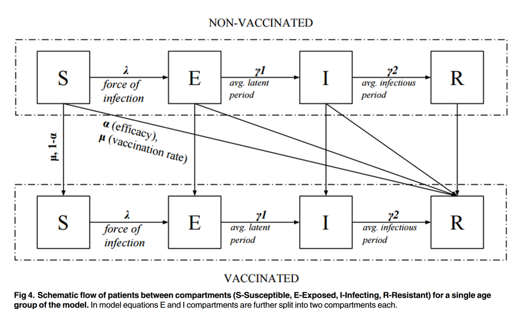

# Bayesian model: summary

# Short tangent: Bayesian statistics recap

Bayesian statistics offers a way of making statements about *probability*, about statistical parameters $\theta$ (or unobserved data), conditional on observed data $y$.

- Step 1: hypothesise a model (joint probability for $\theta$ and $y$)
  - $p(\theta, y) = p(y | \theta)p(\theta)$
- Step 2: condition unobserved quantities on observed data
  - $p(\theta | y) = \frac{p(\theta)p(y | \theta)}{p(y)}$
  - $p(y)$ is a summation over all possible values of $\theta$ (considered a constant and omitted)
- Step 3: criticise the model
  - How well does the model fit data?
  - How does the result depend on assumptions of step 1?
  - Are the conclusions of the result reasonable?

# Short tangent: why go Bayesian?

- Bayesian inference matches common-sense intuitions about meaning of probability, uncertainty and intervals
- Overcomes deficiencies in data (inference on small samples, informative priors)
- Propagates uncertainty
- Avoids problems of Fisher/Neyman-Pearson null hypothesis significance testing (as practiced)

# Result

According to our model (Rajaram *et al*, 2017):

- Vaccinating additional 1-2% of population (targetting children aged 2-3 and primary school age) could result in 6-10% reduction in *overall* influenza rates
- The infection rates decreased across all age groups, which led to similar reductions in hospitalisations (infants and elderly) and deaths (elderly)
- The inferred reduction was variable across seasons and uncertain

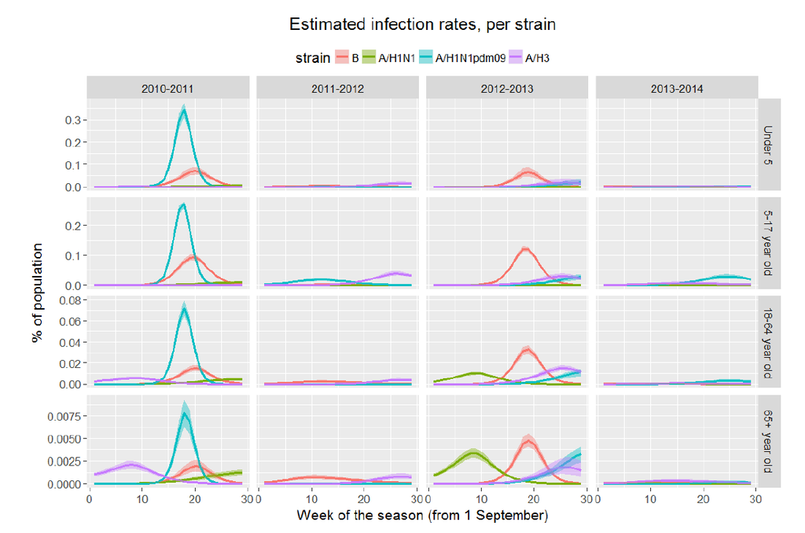

# Capturing uncertainty

Approaches to capturing uncertainty:

- Simple: best vs worst case scenario
- Complicated: Monte Carlo draws over all assumptions
  - How to partition variability vs uncertainty?
  - Depending on the context you will want to set one/both to 0

*Example from an ongoing project: just for visual flavour. Coloured points are estimates of flu burden, over ~10 seasons.*

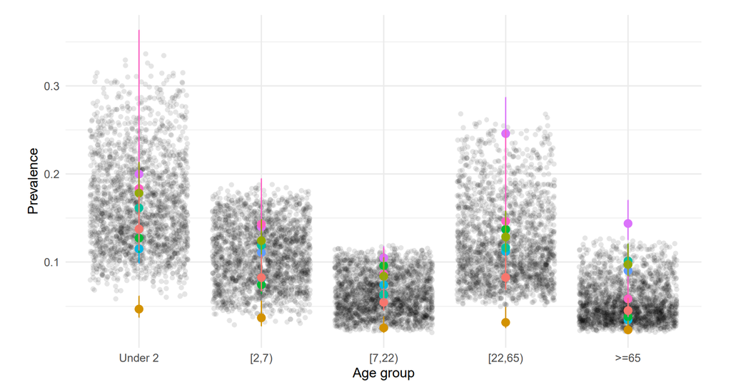

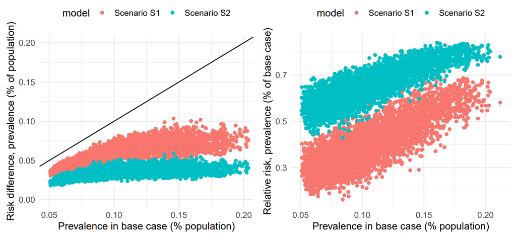

# Other flu modeling work on this

Check out the links in electronic version of the slides

- [Baguelin et al.](https://journals.plos.org/plosmedicine/article?id=10.1371/journal.pmed.1001527) is the original study that outlines Bayesian approach
- [Backer et al.](https://www.sciencedirect.com/science/article/pii/S1755436518300732#!) show how over lifetime the mean risk will decrease, but between-season variation will increase
- [Kassianos et al.](https://www.sciencedirect.com/science/article/pii/S0264410X20308513) discuss evidence over 6 seasons of the UK programme.
- [Weidermann et al.](https://bmcinfectdis.biomedcentral.com/articles/10.1186/s12879-017-2344-6) apply SEIR-type modeling to German context and find smaller than expected impacts

# A lot of COVID modeling work uses similar approaches

Agent-based models used to inform policy from the start, but inference on parameters done using populational models.

- Bayesian approaches to viral parameters
  - Verity et al. estimated time to symptons and IFRs; see in particular Fig 1-3
- Bayesian SEIR inference
  - Example from very early on in the pandemic: [Hauser et al.](https://journals.plos.org/plosmedicine/article?id=10.1371/journal.pmed.1003189)
  - New approaches computationally feasible but required a lot of optimisation
- “DGP”-like Bayesian approach (Imperial College):
  - [Vollmer et al.](http://spiral.imperial.ac.uk/handle/10044/1/78677)
  - [Flaxman et al.](https://www.nature.com/articles/s41586-020-2405-7)
  - R package [epidemia](https://cran.r-project.org/web/packages/epidemia/index.html)
- More Bayesian modeling of NPIs: [Brauner et al. in *Science*](https://www.science.org/doi/full/10.1126/science.abd9338), [Sharma et al. in *Nature*](https://www.nature.com/articles/s41467-021-26013-4?lan=german), [CMMID (LSHTM) in *BMC Medicine*](https://bmcmedicine.biomedcentral.com/articles/10.1186/s12916-020-01872-8)

# Should we trust this (or any) result?

- How bad is our code?
  - UK: debate over Ferguson et al. Imperial College model (used for 15+ years?)
- Variability in virus parameters accounted for?
  - Important to remember this for prediction/decision models
- What happens over longer time-span (viral evolution, loss of immunity later in life)?
  - There is no eradication strategy for flu (or COVID)
  - see the Backer et al. paper cited earlier
- Uncertainty in takeup of an intervention (vaccination, NPI, therapeutic)
  - In the case of flu there were no issues
  - For COVID there is some research; see Brouard et al for some France-specific notes
- Behaviour adjustment (next slide)

# Behavioural adjustment issues

Also called individual/voluntary behaviour change. A lot of debate between epidemiologists and economists. (Some of it not very nice!)

- [Gans](https://www.nber.org/papers/w27632) discusses this as an economist
  - worth checking out [Voxeu summary of his points](https://voxeu.org/article/reproduction-numbers-tend-1-and-reason-could-be-behavioural) (and other articles)
- [Atkeson](https://www.nber.org/papers/w28434) has a more complex model and an empirical result about pandemic fatigue
- math epi modeling solution (?) is via changing contact matrices, see e.g. Prem et al.
  - There is probably much better empirical result than this, just an example

We shouldn’t trust these either—but any model without behaviour adjustment cannot claim to predict impact of policy.